Feature Article

Review Article

Pharmacologic reduction of angiographic

vasospasm in experimental subarachnoid

hemorrhage: systematic review and meta-analysis

Tommaso Zoerle<sup>1</sup>, Don C Ilodigwe<sup>1</sup>, Hoyee Wan<sup>1</sup>, Katarina Lakovic<sup>2</sup>, Mohammed Sabri<sup>2</sup>,

Jinglu Ai<sup>1</sup>and R Loch Macdonald<sup>1,3</sup>

1Division of Neurosurgery, St Michael’s Hospital, Labatt Family Centre of Excellence in Brain Injury and

Trauma Research, Keenan Research Centre of the Li Ka Shing Knowledge Institute of St Michael’s Hospital,

Ontario, Canada; <sup>2</sup>Institute of Medical Science, University of Toronto, Ontario, Canada; <sup>3</sup>Department of

Surgery, University of Toronto, Ontario, Canada

Animal models have been developed to simulate angiographic vasospasm secondary to subarachnoid

hemorrhage (SAH) and to test pharmacologic treatments. Our aim was to evaluate the effect of

pharmacologic treatments that have been tested in humans and in preclinical studies to determine if

animal models inform results reported in humans. A systematic review and meta-analysis of SAH

studies was performed. We investigated predictors of translation from animals to humans with

multivariate logistic regression. Pharmacologic reduction of vasospasm was effective in mice, rats,

rabbits, dogs, nonhuman primates (standard mean difference of �1.74; 95% confidence interval

�2.04 to �1.44) and humans. Animal studies were generally of poor methodologic quality and there

was evidence of publication bias. Subgroup analysis by drug and species showed that statins,

tissue plasminogen activator, erythropoietin, endothelin receptor antagonists, calcium channel

antagonists, fasudil, and tirilazad were effective whereas magnesium was not. Only evaluation

of vasospasm > 3 days after SAH was independently associated with successful translation. We

conclude that reduction of vasospasm is effective in animals and humans and that evaluation

of vasospasm > 3 days after SAH may be preferable for preclinical models.

Journal of Cerebral Blood Flow & Metabolism (2012) 32, 1645–1658; doi:10.1038/jcbfm.2012.57; published online

25 April 2012

Keywords: animal model; pharmacologic reduction; subarachnoid hemorrhage; translation; vasospasm

Introduction

Outcome from aneurysmal subarachnoid hemor-

rhage

(SAH)

has

improved.

Mortality

declined

0.4% per year, after adjustment for age, between

1973 and 2002 (Nieuwkamp et al, 2009). The main

changes in management that have occurred are

improvements in intensive care, early securing of

the ruptured aneurysm, and use of nimodipine.

Many other drugs have been tested in animal models

but none has proven effective in high-quality clinical

trials. Most of these studies tested drugs directed at

reducing angiographic vasospasm. This was based on

the hypothesis that since angiographic vasospasm is

strongly correlated with cerebral infarction (Crowley

et al, 2011) and cerebral infarction is correlated with

unfavorable clinical outcome on the Glasgow outcome

scale (Fergusen and Macdonald, 2007) then reducing

vasospasm should improve clinical outcome.

There are many possible reasons for lack of transla-

tion of reducing angiographic vasospasm in animal

models to improving outcome in humans, including

clinical trial design, whether the animal model

reproduces the disease and methodological flaws

in experimental studies (van der Worp et al, 2010).

Preclinical SAH studies for pharmaceutical reduc-

tion of vasospasm differ in terms of animal used,

Received 14 November 2011; revised 12 February 2012; accepted

28 February 2012; published online 25 April 2012

Correspondence: Dr RL Macdonald, Division of Neurosurgery, St

Michael’s Hospital, University of Toronto, 30 Bond Street, Toronto,

Ontario M5B 1W8, Canada.

E-mail: macdonaldlo@smh.ca

This study was supported by grants from the Physicians Services

Incorporated Foundation and the Heart and Stroke Foundation of

Ontario to RL Macdonald.

induction of SAH, time course and severity of

angiographic vasospasm (Megyesi et al, 2000; Titova

et al, 2009) as well in quality of design (i.e.,

randomization, blinding). All these characteristics

could impact the results of experimental treatment

and perhaps the chance of translation, but to our

knowledge there is no evidence that one model of

SAH is better than any other for the purposes of

predicting whether the findings in the animal study

of a drug in relation to angiographic vasospasm are

the

same

as

what

is

found

for

its

effects

on

angiographic vasospasm in human clinical trials. A

meta-analysis of human clinical trials of drugs to

decrease vasospasm showed that some, but ob-

viously not all drugs tested did reduce vasospasm

in randomized clinical trials (Etminan et al, 2011).

Thus, the primary hypothesis tested here was that

some specific animal model or characteristic of one

predicts the findings in clinical trials. The idea was

that if, for example, one specific species or method of

induction of SAH or some such characteristic of an

animal model was more likely to be associated with

successful translation to prevention of angiographic

vasospasm in humans, then maybe that characteristic

should be used for preclinical studies. The study of

Etminan et al (2011) reported that in the clinical

trials, angiographic vasospasm was reduced but there

was no significant effect on clinical outcome. Thus,

another hypothesis that could be tested would be

what animal models or characteristics of them

correlate with clinical outcome in humans. The

present analysis focuses on angiographic vasospasm.

Materials and methods

We conducted this systematic review and meta-analysis

according to the methods recommended for assessing health

technologies and the Preferred Reporting Items for Systematic

Reviews and Meta-Analyses (PRISMA) guidelines (Higgins and

Green, 2008; Liberati et al, 2009; Mignini and Khan, 2006;

Moher et al, 2009). No language restrictions were used and two

reviewers assessed each reference and determined study

eligibility.

Criteria for Included Animal Studies

Type of studies: We included preclinical studies in vivo

where SAH was simulated by endovascular puncture of a

cerebral artery, subarachnoid clot placement, or injection

of blood, hemolyzed blood or other purported vasospastic

substances into the subarachnoid space.

Type of intervention: We included studies of prophylactic

treatment of angiographic vasospasm with any drug tested

in both experimental and clinical trials for the same

purpose. Intervention was defined as treatment for the

purposes of this study if drug administration was started

before or under the same anesthetic time as when the SAH

was induced in the animal model or within 24 hours of the

last injection of blood into the subarachnoid space. We did

not include studies where drugs were administered to

reverse established angiographic vasospasm. For selecting

drugs, we considered a systematic review of drug treat-

ments for humans with SAH and included all drugs tested

in randomized, blinded clinical trials (Etminan et al, 2011).

Type of outcome: The primary outcome was cerebral

vasospasm evaluated by catheter, CT (computed tomo-

graphic), or magnetic resonance angiography or by histo-

logical methods.

Search Methods for Identification of Studies

Pubmed and Embase were searched from 1966 to Novem-

ber 2010, using the following terms: (subarachnoid hemor-

rhage) AND ((statin) OR (tissue plasminogen activator) OR

(ticlopidine) OR (erythropoietin) OR (clazosentan) OR

(nimodipine) OR (nicardipine) OR (fasudil) OR (tirilazad))

AND (animal OR experimental). The same search was

performed for magnesium, endothelin converting enzyme,

and endothelin receptor antagonist. The reference lists of

the papers were checked to identify other studies not

found in the initial search.

Data Collection

For every included study, we extracted data on the species

and sex of animals, method of induction of SAH, drug

tested, timing and method of delivery of the drug, time and

method for outcome assessment, randomization, blinding,

sample size estimation, inclusion and exclusion criteria

and physiological variables that were measured. Data on

the number of animals and degree of vasospasm in

treatment and control groups were extracted. If in the

same study different doses or delivery way were used, data

on the effect of the intervention were extracted for every

group and the most effective regimen was used for the

analysis, although for assessment of heterogeneity and

publication bias, results for the best as well as all (114

comparisons) are provided. If in the same study different

drugs were tested, data on the effect of each drug were

extracted and analyzed separately. Vasospasm was ex-

pressed as the percent reduction in cerebral artery diameter

from baseline (in the studies where angiographic evalua-

tion was performed) or compared with control values (in

the studies were histological evaluation was performed). If

the degree of vasospasm was expressed as reduction in

artery cross sectional area, the diameter was calculated

using the formula: diameter = 2 � O(area/p). If data were

presented only in figures, then values were estimated using

digital ruler software.

Methodologic quality of the animal studies was assessed

by two reviewers by extracting data on study design,

allocation

concealment,

blinding,

number

of

animals

randomized, age of animals, recording of physiologic

variables, and inclusion of controls. We did not include

funding source since this was not always reported, and we

did not use a checklist and a score to assess study quality.

This was because according to van der Worp et al (2010),

and other sources, use of these is controversial and it is not

clear that any particular characteristics are better than any

others. We also did not extract data on other variables

reported in some other systematic reviews (such as the

neuroprotective effect of anesthesia) because in most

papers there were insufficient data provided.

To assess the effect of each drug in human trials, the data

were obtained from Etminan et al (2011). The outcome

measure was radiographic vasospasm, which was defined

as a focal or generalized reduction of cerebral arterial

caliber on catheter cerebral angiography, or increased

cerebral blood flow velocities on transcranial Doppler

ultrasound. The included studies used various definitions

of angiographic and transcranial Doppler vasospasm, so we

used the definitions reported by the investigators of the

original studies. If the investigators categorized angio-

graphic vasospasm into no/mild, moderate, and severe

vasospasm, we used the number of patients that had

moderate-to-severe vasospasm as an outcome event. Tran-

scranial Doppler vasospasm was defined as flow velocity of

at least 120 cm/s or peak flow velocity of > 200 cm/s. If

studies reported angiographic and transcranial Doppler

vasospasm, the data on angiographic vasospasm were used

(Etminan et al, 2011).

Statistical Analysis

To test which species may reflect more accurately the effect

of drug treatment on reducing vasospasm in humans, we

analyzed the concordance between the drug effect in

human and in the different animals. The drug effect in

humans was defined as focal or generalized reduction in

cerebral

artery

diameter

on

catheter

angiography,

or

increased cerebral blood flow velocities on transcranial

Doppler ultrasound, as reported previously (Etminan et al,

2011). If studies reported both catheter angiography and

Doppler ultrasound, angiography results were used, and

the outcome event was number of patients with moderate

or severe vasospasm. The effects were defined as con-

cordant if the drug showed evidence of positive effect in

humans as well as in animals or no evidence of effect in

humans as well as in animals. Drug effect was defined as

discordant if the drug showed evidence of efficacy in

animals but not in humans or vice versa.

A random effect standardized meta-analysis was used to

assess the effect of pharmacologic reduction of vasospasm

in animal studies. Effect sizes were expressed as pooled

standard mean difference. Subgroup analyses by drug and

animal species were performed. We used meta-regression

to analyze the source of heterogeneity, if any. Factors

included in the meta-regression were species and sex of

animals, method of induction of SAH, drug tested, route of

drug delivery, treatment start time (before or after SAH),

time and method of outcome assessment, randomization,

blinding (for outcome assessment and whether animals

belonged to treatment or control groups before surgery),

monitoring of physiological variables (temperature, blood

pressure, heart rate, oxygenation, intracranial pressure),

and monitoring of CO2 (Table 1).

Publication bias was investigated using Begg’s and

Egger’s tests; Begg’s funnel plots are shown. For human

studies, effect sizes were expressed in pooled risk ratio

estimates. To assess predictors of translation from animal

to human, univariable and multivariable logistic regres-

sions were used

with the

dependent

variable being

concordance/discordance of the drug. Variables entered

in the regressions were the same as the variables used for

meta-regression. Bonferroni correction was used for multi-

ple comparisons. P < 0.05 was considered significant.

Results

A total of 453 studies were identified. Three hundred

nineteen studies were excluded after review of the

title and abstract showed the study was a review

article, clinical studies with no single treatment,

in-vitro study or test of a treatment to reverse

established angiographic vasospasm. An additional

64 studies were excluded after reading the full text

because they did not completely fulfill the inclusion

criteria or they reported preliminary or incomplete

data. Data from 70 papers were then extracted

(Bilginer et al, 2009; Bulsara et al, 2006; Caner et al,

1996; Chang et al, 2010; Chen et al, 2009; Cheng et al,

2009; Chung and Lee, 1993; Cosentino et al, 1993;

Espinosa et al, 1984; Findlay et al, 1988, 1989, 1990;

Grasso et al, 2002; Gul et al, 2010; Hanggi et al, 2009;

Hariton et al, 1993; Hino et al, 1995; Itoh et al, 1993,

1994; Josko et al, 2000; Kanamaru et al, 1990, 1991;

Kawada et al, 1999; Kawashima et al, 2000; Kim et al,

1996, 2000; Kita et al, 1998; Kwan et al, 1997, 2001,

2006; Laslo et al, 2006; Lewis et al, 1988; Lin et al,

2007; Macdonald et al, 1998a,b, 2004; Marbacher et al,

2008; Matsui and Asano, 1994; Matsumura et al,

1991; McGirt et al, 2002, 2006; Mesis et al, 2006;

Murphy et al, 2008; Nirei et al, 1993; Nosko et al,

1985; Ohkuma et al, 1999; Pasqualin et al, 1991;

Roux et al, 1997; Santhanam et al, 2005; Satoh et al,

1992; Seifert et al, 1989; Shigeno et al, 1995; Steinke

et al, 1989; Sugawara et al, 2008; Suzuki et al, 1998,

1999; Takanashi et al, 2001a, b; Tang et al, 2008;

Turowski et al, 2007; Vollmer et al, 1989; Wanebo

et al, 1998; Wanebo et al, 1997; Wang et al, 2010;

Willette et al, 1994; Zabramski et al, 1986; Zimmer-

mann et al, 1996; Zuccarello et al, 1989, 1996, 1998).

In four papers, two drugs were tested, leading to a

total of 74 comparisons for analysis (Cosentino et al,

1993; Hino et al, 1995; Zuccarello et al, 1996, 1998).

There were 556 animals assigned to treatment groups

and 664 to control groups.

Characteristics of the Studies

Investigators used monkeys (Macaca species), dogs

(mongrel

or beagles), rabbits (Japanese

or New

Zealand species), rats (Sprague Dawley or Wistar

species) and mice (Table 1; Supplementary Table 1).

The most used methods to simulate SAH were two

injections of blood into the cisterna magna (dog,

rabbit, and rat studies), a single injection of blood

Table 1 Characteristics of animal studies

Characteristic

Number

(%)

References

Species

Monkey

16 (22)

Espinosa et al (1984); Findlay et al (1988, 1989, 1990); Hariton et al (1993); Hino et al (1995); Kanamaru

et al (1990, 1991); Kim et al (1996); Lewis et al (1988); Macdonald et al (2004); Nosko et al (1985); Steinke

et al (1989); Suzuki et al (1998, 1999)

Dog

23 (31)

Bulsara et al (2006); Chung and Lee (1993); Cosentino et al (1993); Itoh et al (1993, 1994); Kawashima et al

(2000); Kim et al (2000); Kita et al (1998); Macdonald et al (1998a, b); Matsui and Asano (1994);

Matsumura et al (1991); Nirei et al (1993); Ohkuma et al (1999); Roux et al (1997); Satoh et al (1992);

Seifert et al (1989); Shigeno et al (1995); Takanashi et al (2001b); Willette et al (1994); Zabramski et al

(1986); Zimmermann et al (1996)

Rabbit

24 (32)

Bilginer et al (2009); Caner et al (1996); Chen et al (2009); Grasso et al (2002); Kawada et al (1999); Kwan

et al (1997, 2001, 2006); Laslo et al (2006); Lin et al (2007); Marbacher et al (2008); McGirt et al (2006);

Murphy et al (2008); Pasqualin et al (1991); Santhanam et al (2005); Tang et al (2008); Vollmer et al (1989);

Wanebo et al (1997, 1998); Zuccarello et al (1989, 1996, 1998)

Rat

9 (12)

Chang et al (2010); Cheng et al (2009); Gul et al (2010); Hanggi et al (2009); Josko et al (2000); Sugawara

et al (2008); Takanashi et al (2001a); Turowski et al (2007); Wang et al (2010)

Mouse

2 (2)

Sex

Male

27 (36)

Bilginer et al (2009); Chang et al (2010); Cheng et al (2009); Grasso et al (2002); Hanggi et al (2009); Josko

et al (2000); Kwan et al (1997, 2001, 2006); Lin et al (2007); McGirt et al (2002, 2006); Mesis et al (2006);

Murphy et al (2008); Nirei et al (1993); Pasqualin et al (1991); Santhanam et al (2005); Sugawara et al

(2008); Takanashi et al (2001a); Tang et al (2008); Turowski et al (2007); Wanebo et al (1998); Wanebo et al

(1997); Wang et al (2010); Willette et al (1994); Zuccarello et al (1996, 1998)

Female

11 (14)

Espinosa et al (1984); Findlay et al (1988, 1989, 1990); Gul et al (2010); Kanamaru et al (1990, 1991); Lewis

et al (1988); Nosko et al (1985); Steinke et al (1989)

Male/female

36 (49)

Bulsara et al (2006); Caner et al (1996); Chen et al (2009); Chung and Lee (1993); Cosentino et al (1993);

Hariton et al (1993); Hino et al (1995); Itoh et al (1993, 1994); Kawashima et al (2000); Kim et al (1996,

2000); Kita et al (1998); Laslo et al (2006); Macdonald et al (1998a, b, 2004); Marbacher et al (2008); Matsui

and Asano (1994); Matsumura et al (1991); McGirt et al (2006); Ohkuma et al (1999); Roux et al (1997);

Satoh et al (1992); Seifert et al (1989); Shigeno et al (1995); Suzuki et al (1998, 1999); Takanashi et al

(2001b); Vollmer et al (1989); Zabramski et al (1986); Zimmermann et al (1996); Zuccarello et al (1998)

Method of induction of SAH

Clot placement

17 (23)

Espinosa et al (1984); Findlay et al (1988, 1989, 1990); Hariton et al (1993); Hino et al (1995); Kanamaru

et al (1990, 1991, 2000); Kim et al (1996); Lewis et al (1988); Macdonald et al (2004); Nosko et al (1985);

Steinke et al (1989); Suzuki et al (1998, 1999)

2 Injections

cisterna magna

29 (39)

Bulsara et al (2006); Chung and Lee (1993); Cosentino et al (1993); Itoh et al (1993, 1994); Kim et al (2000);

Kita et al (1998); Macdonald et al (1998a, b); Matsui and Asano (1994); Matsumura et al (1991); Nirei et al

(1993); Ohkuma et al (1999); Roux et al (1997); Satoh et al (1992); Seifert et al (1989); Shigeno et al (1995);

Takanashi et al (2001b); Willette et al (1994); Zimmermann et al (1996); Chang et al (2010); Chen et al

(2009); Hanggi et al (2009); Takanashi et al (2001a); Zuccarello et al (1996, 1998)

One injection

cisterna magna

21 (28)

Bilginer et al (2009); Caner et al (1996); Grasso et al (2002); Kawada et al (1999); Kwan et al (1997, 2001,

2006); Laslo et al (2006); Lin et al (2007); Marbacher et al (2008); McGirt et al (2006); Murphy et al (2008);

Pasqualin et al (1991); Santhanam et al (2005); Vollmer et al (1989); Wanebo et al (1997, 1998); Zuccarello

et al (1989); Gul et al (2010); Josko et al (2000); Turowski et al (2007)

Endovascular

perforation

4 (5)

Cheng et al (2009); McGirt et al (2002); Mesis et al (2006); Sugawara et al (2008)

Other<sup>a</sup>

3 (4)

Tang et al (2008); Wang et al (2010); Zabramski et al (1986)

Severity of vasospasm in control group

Mild

16 (22)

Bulsara et al (2006); Chung and Lee (1993); Gul et al (2010); Hariton et al (1993); Itoh et al (1994); Josko

et al (2000); Laslo et al (2006); Marbacher et al (2008); Mesis et al (2006); Murphy et al (2008); Sugawara

et al (2008); Tang et al (2008); Turowski et al (2007); Zimmermann et al (1996); Zuccarello et al (1998)

Moderate

55 (74)

Caner et al (1996); Chang et al (2010); Chen et al (2009); Cheng et al (2009); Cosentino et al (1993);

Espinosa et al (1984); Findlay et al (1989, 1988); Grasso et al (2002); Hanggi et al (2009); Hino et al (1995);

Itoh et al (1993); Kanamaru et al (1990, 1991); Kawada et al (1999); Kawashima et al (2000); Kim et al

(1996, 2000); Kita et al (1998); Kwan et al (1997, 2001, 2006); Lewis et al (1988); Lin et al (2007);

Macdonald et al (1998a, b, 2004); Matsui and Asano (1994); Matsumura et al (1991); McGirt et al (2002,

2006); Nirei et al (1993); Nosko et al (1985); Ohkuma et al (1999); Pasqualin et al (1991); Roux et al (1997);

Santhanam et al (2005); Satoh et al (1992); Seifert et al (1989); Shigeno et al (1995); Steinke et al (1989);

Suzuki et al (1998, 1999); Takanashi et al (2001a, b); Vollmer et al (1989); Wanebo et al (1997, 1998; Wang

et al (2010); Willette et al (1994); Zuccarello et al (1989, 1996)

Severe

3 (4)

Bilginer et al (2009); Findlay et al (1990); Zabramski et al (1986)

Evaluation of vasospasm

Angiography

52 (70)

Bulsara et al (2006); Chung and Lee (1993); Cosentino et al (1993); Espinosa et al (1984); Findlay et al

(1988, 1989, 1990); Hanggi et al (2009); Hariton et al (1993); Hino et al (1995); Itoh et al (1993, 1994);

Kanamaru et al (1990, 1991); Kawada et al (1999); Kawashima et al (2000); Kim et al (1996, 2000);

Table 1

Continued

Characteristic

Number

(%)

References

Kita et al (1998); Laslo et al (2006); Lewis et al (1988); Macdonald et al (1998a, b, 2004); Marbacher et al

(2008); Matsui and Asano (1994); Matsumura et al (1991); Murphy et al (2008); Nirei et al (1993); Nosko

et al (1985); Ohkuma et al (1999); Roux et al (1997); Santhanam et al (2005); Satoh et al (1992); Seifert et al

(1989); Shigeno et al (1995); Steinke et al (1989); Suzuki et al (1998); Suzuki et al (1999); Takanashi et al

(2001b); Tang et al (2008); Turowski et al (2007); Willette et al (1994); Zabramski et al (1986);

Zimmermann et al (1996); Zuccarello et al (1989, 1996, 1998)

Histology

22 (30)

Bilginer et al (2009); Caner et al (1996); Chang et al (2010); Chen et al (2009); Cheng et al (2009); Grasso

et al (2002); Gul et al (2010); Josko et al (2000); Kwan et al (1997, 2001, 2006); Lin et al (2007); McGirt et al

(2002, 2006); Mesis et al (2006); Pasqualin et al (1991); Sugawara et al (2008); Takanashi et al (2001a);

Vollmer et al (1989); Wanebo et al (1998, 1997); Wang et al (2010)

Day of evaluation of vasospasm

3 days

21 (28)

Bilginer et al (2009); Caner et al (1996); Chen et al (2009); Grasso et al (2002); Gul et al (2010); Josko et al

(2000); Kwan et al (1997, 2001, 2006); Lin et al (2007); McGirt et al (2002, 2006); Mesis et al (2006);

Pasqualin et al (1991); Santhanam et al (2005); Sugawara et al (2008); Tang et al (2008); Vollmer et al

(1989); Wanebo et al (1997, 1998); Zuccarello et al (1989)

>3 days

53 (72)

Bulsara et al (2006); Chang et al (2010); Chen et al (2009); Chung and Lee (1993); Cosentino et al (1993);

Espinosa et al (1984); Findlay et al (1988, 1989, 1990); Hanggi et al (2009); Hariton et al (1993); Hino et al

(1995); Itoh et al (1993, 1994); Kanamaru et al (1990, 1991); Kawada et al (1999); Kawashima et al (2000);

Kim et al (1996, 2000); Kita et al (1998); Laslo et al (2006); Lewis et al (1988); Macdonald et al (1998a, b,

2004); Marbacher et al (2008); Matsui and Asano (1994); Matsumura et al (1991); Murphy et al (2008);

Nirei et al (1993); Nosko et al (1985); Ohkuma et al (1999); Roux et al (1997); Satoh et al (1992); Seifert

et al (1989); Shigeno et al (1995); Steinke et al (1989); Suzuki et al (1998 1999); Takanashi et al (2001a, b);

Turowski et al (2007); Wang et al (2010); Willette et al (1994); Zabramski et al (1986); Zimmermann et al

(1996); Zuccarello et al (1989, 1996)

Drug

Tirilazad

8 (11)

Kanamaru et al (1990, 1991); Macdonald et al (1998a); Matsui and Asano (1994); Steinke et al (1989);

Suzuki et al (1999); Vollmer et al (1989); Zuccarello et al (1989)

Calcium

antagonist

14 (19)

Bilginer et al (2009); Espinosa et al (1984); Gul et al (2010); Hanggi et al (2009); Kawashima et al (2000);

Laslo et al (2006); Lewis et al (1988); Marbacher et al (2008); Mesis et al (2006); Nosko et al (1985);

Pasqualin et al (1991); Tang et al (2008); Turowski et al (2007); Zabramski et al (1986)

Erythropoietin

4 (5)

Chen et al (2009); Grasso et al (2002); Murphy et al (2008); Santhanam et al (2005)

Statins

7 (9)

Bulsara et al (2006); Chang et al (2010); Cheng et al (2009); McGirt et al (2002, 2006); Sugawara et al

(2008); Wang et al (2010)

Endothelin

antagonist/

endothelin

converting

enzyme inhibitor

26 (35)

Caner et al (1996); Cosentino et al (1993); Hino et al (1995); Itoh et al (1993, 1994); Josko et al (2000); Kita

et al (1998); Kwan et al (1997, 2001, 2006); Lin et al (2007); Macdonald et al (1998b); Matsumura et al

(1991); Nirei et al (1993); Roux et al (1997); Shigeno et al (1995); Wanebo et al (1997, 1998); Willette et al

(1994); Zimmermann et al (1996); Zuccarello et al (1996, 1998)

Fasudil

4 (5)

Kim et al (2000); Satoh et al (1992); Takanashi et al (2001a, b)

Tissue

plasminogen

activator

9 (12)

Chung and Lee (1993); Findlay et al (1988, 1989, 1990); Hariton et al (1993); Kawada et al (1999); Ohkuma

et al (1999); Seifert et al (1989); Suzuki et al (1998)

Magnesium

1 (1.5)

Macdonald et al (2004)

Other<sup>b</sup>

1 (1.5)

Kim et al (1996)

Route of drug delivery

Intracranial

30 (40)

Chung and Lee (1993); Cosentino et al (1993); Findlay et al (1988, 1989, 1990); Hanggi et al (2009);

Hariton et al (1993); Hino et al (1995); Itoh et al (1994); Josko et al (2000); Kawada et al (1999); Kawashima

et al (2000); Kim et al (1996); Kita et al (1998); Lewis et al (1988); Marbacher et al (2008); Matsumura et al

(1991); Nirei et al (1993); Ohkuma et al (1999); Santhanam et al (2005); Seifert et al (1989); Suzuki et al

(1998); Takanashi et al (2001a, b); Turowski et al (2007); Willette et al (1994); Zuccarello et al (1998)

Systemic

44 (60)

Bilginer et al (2009); Bulsara et al (2006); Caner et al (1996); Chang et al (2010); Chen et al (2009); Cheng

et al (2009); Espinosa et al (1984); Grasso et al (2002); Gul et al (2010); Itoh et al (1993); Kanamaru et al

(1990, 1991); Kim et al (2000); Kwan et al (1997, 2001, 2006); Laslo et al (2006); Lin et al (2007);

Macdonald et al (1998a, b, 2004); Matsui and Asano (1994); McGirt et al (2002, 2006); Mesis et al (2006);

Murphy et al (2008); Nosko et al (1985); Pasqualin et al (1991); Roux et al (1997); Satoh et al (1992);

Shigeno et al (1995); Steinke et al (1989); Sugawara et al (2008); Suzuki et al (1999); Tang et al (2008);

Vollmer et al (1989); Wanebo et al (1997, 1998); Wang et al (2010); Zabramski et al (1986); Zimmermann

et al (1996); Zuccarello et al (1989, 1996)

Pretreatment

Before induction

of SAH

7 (9)

Caner et al (1996); Chang et al (2010); Cheng et al (2009); Itoh et al (1993, 1994); McGirt et al (2002);

Vollmer et al (1989)

After induction

of SAH

67 (91)

Bilginer et al (2009); Bulsara et al (2006); Chen et al (2009); Chung and Lee (1993); Cosentino et al (1993);

Espinosa et al (1984); Findlay et al (1988, 1989, 1990); Grasso et al (2002); Gul et al (2010); Hanggi et al

(2009); Hariton et al (1993); Hino et al (1995); Josko et al (2000); Kanamaru et al (1990, 1991); Kawada et al

(1999); Kawashima et al (2000); Kim et al (1996, 2000); Kita et al (1998); Kwan et al (1997, 2001, 2006);

Table 1

Continued

Characteristic

Number

(%)

References

Laslo et al (2006); Lewis et al (1988); Lin et al (2007); Macdonald et al (1998a, b, 2004); Marbacher et al

(2008); Matsui and Asano (1994); Matsumura et al (1991); McGirt et al (2006); Mesis et al (2006); Murphy

et al (2008); Nirei et al (1993); Nosko et al (1985); Ohkuma et al (1999); Pasqualin et al (1991); Roux et al

(1997); Santhanam et al (2005); Satoh et al (1992); Seifert et al (1989); Shigeno et al (1995); Steinke et al

(1989); Sugawara et al (2008); Suzuki et al (1998, 1999); Takanashi et al (2001a, b); Tang et al (2008);

Turowski et al (2007); Wanebo et al (1997, 1998); Wang et al (2010); Willette et al (1994); Zabramski et al

(1986); Zimmermann et al (1996); Zuccarello et al (1998, 1989, 1996)

Blinding of outcome

No

29 (40)

Chen et al (2009); Cosentino et al (1993); Gul et al (2010); Itoh et al (1993, 1994); Josko et al (2000); Kim

et al (2000); Kita et al (1998); Laslo et al (2006); Matsui and Asano (1994); Matsumura et al (1991); McGirt

et al (2006); Murphy et al (2008); Ohkuma et al (1999); Pasqualin et al (1991); Roux et al (1997);

Santhanam et al (2005); Satoh et al (1992); Seifert et al (1989); Shigeno et al (1995); Takanashi et al (2001a);

Tang et al (2008); Turowski et al (2007); Vollmer et al (1989); Wanebo et al (1997); Wang et al (2010); Willette

et al (1994); Zabramski et al (1986); Zimmermann et al (1996); Zuccarello et al (1989, 1998)

Yes

45 (60)

Bilginer et al (2009); Bulsara et al (2006); Caner et al (1996); Chang et al (2010); Cheng et al (2009); Chung

and Lee (1993); Espinosa et al (1984); Findlay et al (1988, 1989, 1990; Grasso et al (2002); Hanggi et al

(2009); Hariton et al (1993); Hino et al (1995); Kanamaru et al (1990, 1991); Kawada et al (1999);

Kawashima et al (2000); Kim et al (1996); Kwan et al (1997, 2001, 2006); Lewis et al (1988); Lin et al

(2007); Macdonald et al (1998a, b, 2004); Marbacher et al (2008); McGirt et al (2002); Mesis et al (2006);

Nirei et al (1993); Nosko et al (1985); Steinke et al (1989); Sugawara et al (2008); Suzuki et al (1998, 1999);

Takanashi et al (2001a, b); Turowski et al (2007); Wanebo et al (1997, 1998); Wang et al (2010); Zuccarello

et al (1996)

Blinding to induction of SAH versus saline/sham surgery

No

59 (80)

Bulsara et al (2006); Caner et al (1996); Chang et al (2010); Chen et al (2009); Cheng et al (2009); Chung

and Lee (1993); Cosentino et al (1993); Espinosa et al (1984); Findlay et al (1989, 1990); Grasso et al

(2002); Gul et al (2010); Hanggi et al (2009); Itoh et al (1993, 1994); Josko et al (2000); Kanamaru et al

(1990, 1991); Kawada et al (1999); Kim et al (2000); Kita et al (1998); Kwan et al (1997); Kwan et al (2001,

2006); Laslo et al (2006); Lewis et al (1988); Lin et al (2007); Marbacher et al (2008); Matsui and Asano

(1994); Matsumura et al (1991); McGirt et al (2002, 2006); Mesis et al (2006); Murphy et al (2008); Nirei

et al (1993); Ohkuma et al (1999); Pasqualin et al (1991); Roux et al (1997); Santhanam et al (2005); Satoh

et al (1992); Seifert et al (1989); Shigeno et al (1995); Sugawara et al (2008); Suzuki et al (1998, 1999);

Takanashi et al (2001a); Tang et al (2008); Turowski et al (2007); Vollmer et al (1989); Wanebo et al (1998,

1997); Wang et al (2010); Willette et al (1994); Zabramski et al (1986); Zimmermann et al (1996);

Zuccarello et al (1989, 1996, 1998)

Yes

15 (20)

Bilginer et al (2009); Findlay et al (1988); Hariton et al (1993); Hino et al (1995); Kawashima et al (2000);

Kim et al (1996); Macdonald et al (1998a, b, 2004); Nosko et al (1985); Steinke et al (1989); Takanashi et al

(2001a, b)

Inclusion and exclusion criteria

No

65 (88)

Bilginer et al (2009); Bulsara et al (2006); Chen et al (2009); Cosentino et al (1993); Espinosa et al (1984);

Findlay et al (1988, 1989, 1990); Grasso et al (2002); Gul et al (2010); Hanggi et al (2009); Hariton et al

(1993); Hino et al (1995); Itoh et al (1993, 1994); Josko et al (2000); Kanamaru et al (1990, 1991); Kawada

et al (1999); Kawashima et al (2000); Kim et al (1996); Kim et al (2000); Kita et al (1998); Kwan et al (2001,

2006); Laslo et al (2006); Lewis et al (1988); Lin et al (2007); Macdonald et al (1998a, b, 2004); Marbacher

et al (2008); Matsui and Asano (1994); Matsumura et al (1991); McGirt et al (2006); Mesis et al (2006);

Murphy et al (2008); Nirei et al (1993); Nosko et al (1985); Ohkuma et al (1999); Pasqualin et al (1991);

Roux et al (1997); Santhanam et al (2005); Satoh et al (1992); Seifert et al (1989); Shigeno et al (1995);

Steinke et al (1989); Suzuki et al (1998, 1999); Takanashi et al (2001a, b); Tang et al (2008); Turowski et al

(2007); Vollmer et al (1989); Wang et al (2010); Willette et al (1994); Zabramski et al (1986); Zimmermann

et al (1996); Zuccarello et al (1989, 1996, 1998)

Yes

9 (12)

Caner et al (1996); Chang et al (2010); Cheng et al (2009); Chung and Lee (1993); Kwan et al (1997); McGirt

et al (2002); Sugawara et al (2008); Wanebo et al (1997, 1998)

Randomization

No

36 (49)

Bilginer et al (2009); Caner et al (1996); Cheng et al (2009); Chung and Lee (1993); Cosentino et al (1993);

Grasso et al (2002); Gul et al (2010); Itoh et al (1993, 1994); Josko et al (2000); Kawada et al (1999); Kim

et al (2000); Kwan et al (1997, 2001, 2006); Lin et al (2007); Matsui and Asano (1994); Matsumura et al

(1991); Murphy et al (2008); Nirei et al (1993); Ohkuma et al (1999); Pasqualin et al (1991); Santhanam

et al (2005); Satoh et al (1992); Seifert et al (1989); Suzuki et al (1998); Takanashi et al (2001a); Turowski

et al (2007); Wang et al (2010); Willette et al (1994); Zabramski et al (1986); Zimmermann et al (1996);

Zuccarello et al (1998, 1989, 1996)

Yes

38 (51)

Bulsara et al (2006); Chang et al (2010); Chen et al (2009); Espinosa et al (1984); Findlay et al (1988, 1989,

1990); Hanggi et al (2009); Hariton et al (1993); Hino et al (1995); Kanamaru et al (1990, 1991); Kawashima

et al (2000); Kim et al (1996); Kita et al (1998); Laslo et al (2006); Lewis et al (1988); Macdonald et al

(1998a, b, 2004); Marbacher et al (2008); McGirt et al (2002, 2006); Mesis et al (2006); Nosko et al (1985);

Roux et al (1997); Shigeno et al (1995); Steinke et al (1989); Sugawara et al (2008); Suzuki et al (1999);

Takanashi et al (2001a,b); Tang et al (2008); Vollmer et al (1989); Wanebo et al (1997, 1998); Wang et al (2010)

into the cisterna magna (rabbit and rat studies) and

craniotomy followed by clot placement around the

cerebral arteries (all monkey and one dog studies). In

the other studies, endovascular perforation (rat and

mouse studies), prechiasmatic cistern blood injec-

tion (one rat study) (Wang et al, 2010) or modified

versions of cisterna magna injection (one rat (Tang

et al, 2008) and one dog study) (Zabramski et al, 1986)

were used. No studies injected hemolyzed blood or

other substances into the subarachnoid space. In 48

studies (52 experiments), vasospasm was assessed

using catheter or CT angiography while 22 used

histology. In 49 studies (53 experiments), vasospasm

was evaluated > 3 days after SAH and in 21 experi-

ments evaluation was performed before or on day 3.

The degree of vasospasm in the control group was

mild (<33%) in 16 experiments, moderate (33 to 66%)

in 55 and severe (>66%) in three.

Drugs tested included tirilazad, tissue plasmino-

gen activator, calcium channel antagonists (nimodi-

pine or nicardipine), erythropoietin, statins, fasudil,

endothelin antagonists, or endothelin converting

enzyme inhibitors, magnesium, and in one study,

tissue plasminogen activator plus an endothelin

antagonist. There were no experimental studies of

ticlopidine. Drugs were administered intracranially

in 30 experiments and systemically in 44 (intravenous,

oral, or intraperitoneal). In seven cases, treatment was

started before the induction of SAH (pretreatment).

Regarding the quality of the studies, none clearly

reported

a

sample

size

calculation.

Only

12%

described inclusion and exclusion criteria, 51%

used

randomization,

20%

reported

blinding

of

whether animals belonged to treatment or control

group before surgery, and 60% reported blinding of

assessment of outcome. Two or more of five physio-

logical variables (heart rate, blood pressure, body

temperature,

intracranial

pressure,

oxygenation)

were monitored in 80% of studies and blood or

end-tidal CO2 was monitored in 78%.

Overall Treatment Effect

The pooled effect size expressed as standard mean

difference showed that pharmacologic treatments

significantly reduced cerebral vasospasm in the

experimental studies (standard mean difference of

�1.74;. 95% CI (confidence interval) �2.04 to �1.44;

Figure 1). Substantial and significant heterogeneity

was

detected

(heterogeneity

w<sup>2</sup>

statistic = 340.60

(degrees of freedom = 73), P = 0.0001). In univariate

meta-regression including all characteristics reported

in Table 1, only the use of calcium antagonists

(nicardipine or nimodipine) showed a significant

association with the pooled effect size. Blinding

induction of SAH revealed a marginal association

(P= 0.052). In the multivariate meta-regression includ-

ing study factors with Pr0.15, treatment with calcium

antagonists remained significantly associated with the

pooled effect size (Supplementary Table 1).

Subgroup Analysis by Drug

Subgroup analysis by drug showed that every drug

except magnesium was effective for reducing vasos-

pasm. Heterogeneity was detected for every subgroup

except for fasudil (Figure 2). Meta-regression was

Table 1

Continued

Characteristic

Number

(%)

References

Monitoring of physiologic variables

No

15 (20)

Chang et al (2010); Cosentino et al (1993); Gul et al (2010); Itoh et al (1993, 1994); Josko et al (2000);

Kawada et al (1999); Kim et al (2000); Kita et al (1998); Matsumura et al (1991); McGirt et al (2006);

Ohkuma et al (1999); Seifert et al (1989); Turowski et al (2007)

Yes

59 (80)

Bilginer et al (2009); Bulsara et al (2006); Caner et al (1996); Chen et al (2009); Cheng et al (2009); Chung

and Lee (1993); Espinosa et al (1984); Findlay et al (1988, 1989, 1990); Grasso et al (2002); Hanggi et al

(2009); Hariton et al (1993); Hino et al (1995); Kanamaru et al (1990, 1991); Kawashima et al (2000); Kim

et al (1996); Kwan et al (1997, 2001, 2006); Laslo et al (2006); Lewis et al (1988); Lin et al (2007);

Macdonald et al (1998a, b, 2004); Marbacher et al (2008); Matsui and Asano (1994); McGirt et al (2002);

Mesis et al (2006); Murphy et al (2008); Nirei et al (1993); Nosko et al (1985); Pasqualin et al (1991); Roux

et al (1997); Santhanam et al (2005); Satoh et al (1992); Shigeno et al (1995); Steinke et al (1989); Sugawara

et al (2008); Suzuki et al (1998, 1999); Takanashi et al (2001a, b); Tang et al (2008); Vollmer et al (1989);

Wanebo et al (1997, 1998); Wang et al (2010); Willette et al (1994); Zabramski et al (1986); Zimmermann

et al (1996); Zuccarello et al (1989, 1996, 1998)

Monitoring CO2

No

16 (22)

Bulsara et al (2006); Cosentino et al (1993); Kim et al (2000); Matsumura et al (1991); Ohkuma et al (1999)

Yes

58 (78)

Chang et al (2010); Cheng et al (2009); Gul et al (2010); Hanggi et al (2009); Josko et al (2000); Kawada et al

(1999); McGirt et al (2006); Mesis et al (2006); Takanashi et al (2001a); Turowski et al (2007); Wang et al

(2010)

SAH, subarachnoid hemorrhage.

aModified cisterna magna injection and prechiasmatic cistern injection.

bTissue plasminogen activator plus endothelin antagonist.

conducted for drug type versus variables signifi-

cantly (P < 0.05) associated in univariate analysis.

This showed that the effect of erythropoietin and

statins were associated with the method of induction

of SAH, while calcium antagonist effect was related

to the use of monkeys and mice (Table 2). This means

that the effect of erythropoietin and statins are

different (higher for statins, smaller for erythropoie-

tin) in studies where cisterna magna double injection

model was used compared with studies where cisterna

magna single injection was used and that effect of

calcium channel antagonists were different in studies

where monkeys (smaller effect) or mice (higher effect)

where used compared with the other studies.

Subgroup Analysis by Species

Subgroup analysis by species showed that pharmaco-

logic treatment was effective in all species (Figure 2).

Again, heterogeneity was detected and meta-regression

showed that the pooled effect in rats was associated

with the method of induction of SAH, in dogs with

use of tissue plasminogen activator, and in monkeys

with tirilazad and severity of vasospasm (Table 2).

The heterogeneity means that in rats, treatment effect

was higher when cisterna magna models were used,

that in dogs, tissue plasminogen activator was more

effective than other drugs, and that in monkeys,

tirilizad was more effective compared with other

drugs and that treatment effect was higher when

drugs where tested against severe vasospasm.

Publication Bias

Both the Begg’s (z-score continuity corrected 6.68,

P = 0.000) and Egger’s test (bias coefficient �4.83;

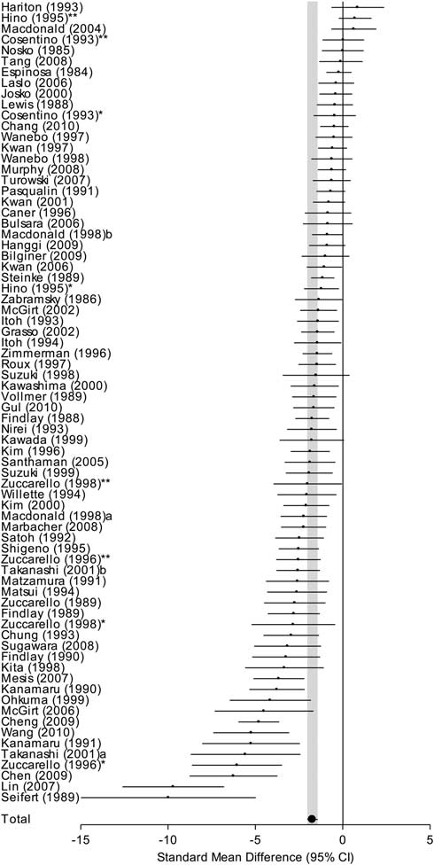

Figure 1 Effect size of 74 animal studies of pharmacologic

reduction of vasospasm included in meta-analysis. Gray band

represents overall effect with 95% confidence intervals (* and

** are effect of different drugs in the same publication).

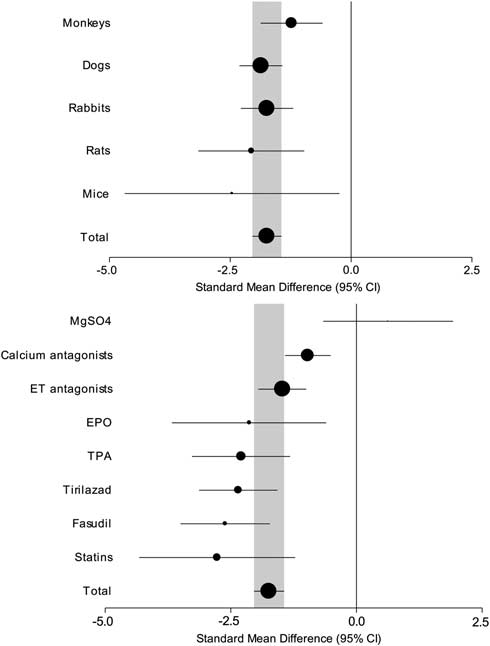

Figure 2 Effect size of the 74 included studies grouped by

animal and drug. Gray band represents overall effect with 95%

confidence interval. The size of the circle reflects the number of

animals included in the different subgroups (ET antagonist:

endothelin

antagonist

and

endothelin

converting

enzyme

inhibitor, MgSO4: magnesium).

95% CI �5.96 to �3.69; P = 0.000) of heterogeneity in

the 74 most effective doses in the pooled studies

returned

strong

evidence

of

The

results were similar when including all 114 dose

regimens tested (Begg’s z-score continuity corrected

8.18, P = 0.000 and Egger’s test bias coefficient �4.79;

95% CI �5.75 to �3.84; P = 0.000). Furthermore,

Begg’s funnel plot showing asymmetric orientation of

the data points for both analyses (Figure 3).

Treatment Effect of Different Drugs in Different Species

and Translation

Considering separately the effect of the different

drugs in the different species, it is interesting to note

that calcium antagonists and endothelin antagonists

showed no significant effect in monkeys, statins had

no significant effect in dogs, and endothelin antago-

nists had no significant effects in rats (Table 3).

Therefore, the argument that all drugs are effective in

animal models is not correct. We next considered data

in a systematic review of the effect of pharmaceutical

reduction of radiographic vasospasm with different

drugs in human clinical trials (Etminan et al, 2011).

Drug effects were classified as concordant or dis-

cordant based simply on whether or not the study

or group of studies demonstrated a statistically

significant effect on vasospasm. If, for example, the

drug reduced vasospasm in dogs and in humans, or

did not do so in either, then it was concordant. Any

other result was discordant. Fasudil, endothelin

antagonists (clazosentan), and tissue plasminogen

activator showed a beneficial effect on angiographic

vasospasm in humans while calcium antagonists

(nimodipine and nicardipine), erythropoietin, statins,

and tirilizad showed no significant effect (Table 3).

Since no data were available on the effects of

magnesium and tissue plasminogen activator plus

endothelin

antagonists,

experiments

using

treatments were excluded from further analysis.<sup>these</sup>

Two of the four drugs (50%) tested in monkeys

presented results concordant with clinical trials

(calcium channel antagonists had no significant

effects in either, tissue plasminogen activator was

significantly effective in both). In dogs, four (statins

had no significant effects whereas fasudil, tissue

plasminogen activator, and endothelin antagonists/

endothelin converting enzyme inhibitors had sig-

nificant effects) of six drugs (67%) were concordant

and in rabbits, two (tissue plasminogen activator and

Table 2 Subgroup analysis by drug and species

Drug

Variable

Regression

coefficient

(95% confidence

interval)

P-value

Erythropoietin

Single versus

double

Cisterna magna

injection

5.31

(2.50 to 8.13)

0.000

Calcium channel

antagonists

Monkeys

0.78

(0.14 to 1.42)

0.017

Mice

�2.78

(�4.26 to �1.29)

0.000

Statin

Single versus

double

Cisterna magna

injection

4.38

(�1.55 to �7.21)

0.002

Species

Variable

Regression

coefficient

(95% confidence

interval)

P-value

Dog

Tissue

plasminogen

Activator

�2.06

(�3.66 to �0.46)

0.012

Monkey

Tirilazad

�1.85

(�3.39 to �0.30)

0.019

Vasospasm

severity

�2.22

(�4.20 to �0.23)

0.029

Rat

Single versus

double

Cisterna magna

injection

4.17

(0.76 to 7.59)

0.017

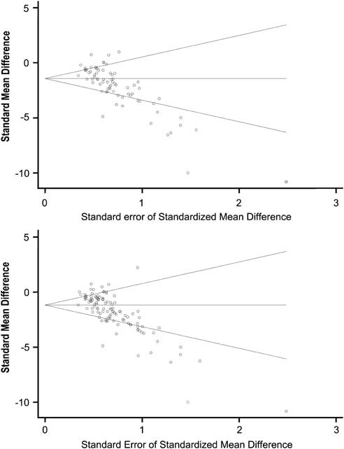

Figure 3 Begg’s funnel plots with pseudo 95% confidence limits

for 74 (upper) or 114 (lower) dose regimen comparisons.

endothelin antagonists had significant effects) of six

(33%). One drug (fasudil had significant effect) of

four (25%) was concordant in rats while in mice,

none of two was concordant (Table 3). Considering

animal studies individually, 55% were concordant.

In multivariate logistic regression after using a

Bonferroni adjustment for multiple testing, the only

significant predictor of translation was the day of

assessment of vasospasm (continuous or dichoto-

mized r versus > 3 days). Studies where vasospasm

was evaluated after day 3 from SAH have results

more concordant with human trials than others.

Univariate analysis showed angiographic evaluation

of vasospasm (versus histology), intracranial delivery

of drug (versus other routes), use of randomization,

statement of inclusion and exclusion criteria, cister-

nal injection procedure or fresh blood injection

(versus clot placement), and blinding of assessment

of translation (P < 0.15; Table 4; Supplementary

Figure 1).

Discussion

This systematic review found that pharmacologic

treatments that are effective at reducing vasospasm

in animal models of SAH are also usually effective in

humans. However, publication bias was detected,

suggesting that some studies remain unpublished

and that the data may overestimate the true effect of

the drugs. Since one of the objectives of animal

experimentation is to develop new treatment for

human

disease,

lack

of

publishing

of

negative

experimental studies may contribute substantially

to unsuccessful translation of results to humans

(Sena et al, 2010; van der Worp et al, 2010). On the

other hand, methodologic quality of many of the

studies was poor, and would limit the interpretation

of experimental studies showing treatment benefits,

as well as of those showing no benefit. We also found

significant heterogeneity and that the effect size was

related to some of the study characteristics. The type

of SAH model for erythropoietin and statins, animal

Table 3 Treatment effect of different drugs in different species

Species

Calcium

channel

antagonist

Statins

Erythropoietin

Tissue

plasminogen

activator

Tirilazad

Fasudil

Endothelin

antagonist/enzyme

inhibitor

Human

0.85

0.85

0.85

0.54

0.92

0.62

0.60

Risk ratio (95% CI)

0.66; 1.08

0.55; 1.31

0.51; 1.41

0.33; 0.88

0.76; 1.11

0.46; 0.83

0.50; 0.73

Monkey

�0.25

Not tested

Not tested

�1.77

�2.90

Not tested

�0.26

Standard mean

difference (95% CI)

�0.77; 0.28

Not tested

Not tested

�3.21; �0.34

�4.60; �1.19

Not tested

�2.23; 1.71

Dog

�1.62

�0.97

Not tested

�5.30

�2.54

�3.10

�1.66

Standard mean

difference (95% CI)

�2.58; �0.65

�2.38; 0.44

Not tested

�8.43; �2.18

�3.58; �1.51

�4.73; �1.47

�2.17; �1.14

Rabbit

�0.89

�4.99

�2.29

�2.04

�2.21

Not tested

�2.20

Standard mean

difference (95% CI)

�1.58; �0.19

�7.73; 2.25

�3.91; �0.67

�3.84; �0.24

�3.38; �1.05

Not tested

�3.22; �1.18

Rat

�1.08

�3.51

Not tested

Not tested

Not tested

�2.67

�0.42

Standard mean

difference (95% CI)

�1.72; �0.45

�6.21; �0.80

Not tested

Not tested

Not tested

�3.91; �1.43

�1.35; 0.52

Mouse

�3.80

�1.46

Not tested

Not tested

Not tested

Not tested

Not tested

Standard mean

difference (95% CI)

�5.24; �2.36

�2.51; �0.40

Not tested

Not tested

Not tested

Not tested

Not tested

CI, confidence interval.

Table 4 Results of univariate and multivariate logistic regression for predictors of translation

Variable

Univariate analysis

Multivariate analysis

P-value

Unadjusted odds ratio

(95% confidence interval)

P-value

Unadjusted odds ratio

(95% confidence interval)

Angiography versus histology

0.0039

5.04 (1.68; 15.11)

Not significant

Fresh blood versus clot placement

0.1490

1.96 (0.65; 5.90)

Not significant

Day of vasospasm evaluation

Continuous

0.0056

1.38 (1.10; 1.74)

0.0006

1.62 (1.23; 2.14)

> 3 versus #3 days

0.0019

6.22 (1.96; 19.7)

0.0002

11.2 (3.13; 40.1)

Drug delivery (intracranial versus systemic)

0.0750

2.40 (0.92; 6.29)

Not significant

Randomization

0.1007

0.46 (0.18; 1.16)

Not significant

Blinding outcome

0.1149

0.46 (0.18; 1.21)

Not significant

Inclusion/exclusion criteria

0.0578

0.20 (0.04; 1.05)

Not significant

species

for

calcium

channel

antagonists,

tissue

plasminogen activator for dogs, tirilizad and severity

of vasospasm for monkeys were significantly differ-

ent. This observation suggests that results of experi-

mental studies are related not only to the drug tested

but also to the study design and quality and that

these factors should be considered when evaluating

whether to test a drug in humans.

The other main objective of this work was to assess

if any animal used in models of SAH more accurately

reflects results of human studies. We observed that

not every drug is effective in every species and that

in monkey and dog studies the concordance with

human studies was higher. However, in multivariate

logistic regression after adjustment for multiple

testing, only the day of evaluation of vasospasm

( > 3 days after SAH) correlated with successful

translation of results to humans. These observations

have practical implications for study design and

model selection and it may be that in further

preclinical experiments long-term drug effect evalua-

tion should be preferred.

There are a number of limitations to this analysis.

Most instances of concordance were positive, in that

drugs worked in animals and humans. However,

additional important confirmatory data would be

studies showing that drugs that were not effective in

humans also were not in animals. In studies that

show no effect, drug dose, timing and route of

administration would also need to be fully explored

or at least shown to be equivalent between animal

and human studies. There are limited data on some

studies use them. Given the paucity of data, we

cannot exclude the possibility that these models are

equal to dogs and monkeys in terms of translation of

results to human. In human trials, angiographic

vasospasm frequently was considered as a dichot-

omous

variable

(none/mild

or

moderate/severe),

while

in

animal

studies,

it

is

expressed

as

continuous variable. For this reason, it was not<sup>a</sup>

possible to compare exactly the effects in animals

and humans. We focused on prophylactic treatments

and in the human studies, drugs were administered

before the onset of angiographic vasospasm. In the

animal studies, however, since we included some

studies where drug administration began after the

second blood injection and angiography was not

done, it is possible that some of these studies were

also treating established vasospasm. The classifica-

tion of drugs also could be questioned. We categor-

ized magnesium separately since it has calcium

antagonist

and

putative

neuroprotective

effects.

Another option would be to include it in the calcium

antagonist category. For calcium antagonists, we

searched only for nimodipine and nicardipine since

other calcium antagonists have not been studied in

randomized clinical trials in humans.

Another issue is the analysis was restricted to

evaluation of angiographic or large-artery vasospasm.

Most models of SAH differ from human SAH in that

animals do not develop cerebral infarctions or other

delayed processes that are proposed to be important

in humans, such as cortical spreading ischemia and

microthromboembolism (Dreier et al, 2009; Vergou-

wen et al, 2008). The end points in human clinical

trials are usually clinical outcome and delayed

cerebral ischemia but neurological and functional

examination after experimental SAH is still uncom-

monly used (Jeon et al, 2009; Takata et al, 2008).

There is some evidence that reduction of angio-

graphic vasospasm does not correlate with improved

outcome in humans (Etminan et al, 2011; Macdo-

nald, 2011; Macdonald et al, 2008). Unfortunately, if

this is true and not due to other reasons, such as

efficacy of rescue therapy in placebo groups, insen-

sitive outcome measures, drug side-effects and such,

animal models will have to be reassessed to ensure

they reflect relevant human features if they are to be

used to decide whether to advance drugs into clinical

trials. The present analysis focused on angiographic

vasospasm but subsequent analysis might examine

the relation between delayed cerebral ischemia and

neurological outcome in animals and humans.

In conclusion, we found evidence that animal

models can inform effects of pharmacologic treat-

ments for angiographic vasospasm in human clinical

trials. Higher species, longer durations of assessment

of vasospasm and injections of fresh blood may be

more applicable.

Disclosure/conflict of interest

RL Macdonald is a consultant for Actelion Pharma-

ceuticals and Chief Scientific Officer of Edge Thera-

peutics, Inc. Edge Therapeutics is dedicated to

developing drugs to improve outcome of patients

with subarachnoid hemorrhage and brain injuries.

References

Bilginer B, Onal MB, Narin F, Soylemezoglu F, Ziyal IM,

Ozgen T (2009) The effects of intravenous cilostazol and

nimodipine on cerebral vasospasm after subarachnoid

hemorrhage in an experimental rabbit model. Turk

Neurosurg 19:374–9

Bulsara KR, Coates JR, Agrawal VK, Eifler DM, Wagner-

Mann CC, Durham HE, Fine DM, Toft K (2006) Effect of

combined simvastatin and cyclosporine compared with

simvastatin alone on cerebral vasospasm after subar-

achnoid hemorrhage in a canine model. Neurosurg

Focus 21:E11

Caner HH, Kwan AL, Arthur A, Jeng AY, Lappe RW, Kassell

NF, Lee KS (1996) Systemic administration of an

inhibitor of endothelin-converting enzyme for attenua-

tion of cerebral vasospasm following experimental

subarachnoid hemorrhage. J Neurosurg 85:917–22

Chang CZ, Wu SC, Lin CL, Hwang SL, Howng SL, Kwan AL

(2010)

Atorvastatin

preconditioning

attenuates

the

production of endothelin-1 and prevents experimental

vasospasm in rats. Acta Neurochir (Wien) 152:1399–406

Chen G, Zhang S, Shi J, Ai J, Hang C (2009) Effects of

recombinant human erythropoietin (rhEPO) on JAK2/

STAT3 pathway and endothelial apoptosis in the rabbit

basilar artery after subarachnoid hemorrhage. Cytokine

45:162–8

Cheng G, Wei L, Zhi-Dan S, Shi-Guang Z, Xiang-Zhen L

(2009) Atorvastatin ameliorates cerebral vasospasm and

early brain injury after subarachnoid hemorrhage and

inhibits caspase-dependent apoptosis pathway. BMC

Neurosci 10:7

Chung WY, Lee LS (1993) The effect of tissue plasminogen

activator

(t-PA)

on

cerebral

vasospasm

in

canine

subarachnoid hemorrhage. Chung Hua i Hsueh Tsa

Chih 52:298–306

Cosentino F, McMahon EG, Carter JS, Katusic ZS (1993)

Effect of endothelinA-receptor antagonist BQ-123 and

phosphoramidon on cerebral vasospasm. J Cardiovasc

Pharmacol 22(Suppl 8):S332–5

Crowley RW, Medel R, Dumont AS, Ilodigwe D, Kassell NF,

Mayer SA, Ruefenacht D, Schmiedek P, Weidauer S,

Pasqualin A, Macdonald RL (2011) Angiographic vasos-

pasm is strongly correlated with cerebral infarction after

subarachnoid hemorrhage. Stroke 42:919–23

Dreier JP, Major S, Manning A, Woitzik J, Drenckhahn C,

Steinbrink J, Tolias C, Oliveira-Ferreira AI, Fabricius M,

Hartings JA, Vajkoczy P, Lauritzen M, Dirnagl U, Bohner

G, Strong AJ (2009) Cortical spreading ischaemia is a

novel process involved in ischaemic damage in patients

with

aneurysmal

subarachnoid

haemorrhage.

Brain

132:1866–81

Espinosa F, Weir B, Overton T, Castor W, Grace M, Boisvert

D (1984) A randomized placebo-controlled double-blind

trial of nimodipine after SAH in monkeys. Part 1:

clinical and radiological findings. J Neurosurg 60:

1167–1175

Etminan N, Vergouwen MD, Ilodigwe D, Macdonald RL

(2011) Effect of pharmaceutical treatment on vasospasm,

delayed cerebral ischemia, and clinical outcome in

patients with aneurysmal subarachnoid hemorrhage: a

systematic review and meta-analysis. J Cereb Blood

Flow Metab 31:1443–51

Fergusen S, Macdonald RL (2007) Predictors of cerebral

infarction in patients with aneurysmal subarachnoid

hemorrhage. Neurosurgery 60:658–67

Findlay JM, Weir BK, Gordon P, Grace M, Baughman R

(1989) Safety and efficacy of intrathecal thrombolytic

therapy in a primate model of cerebral vasospasm.

Neurosurgery 24:491–8

Findlay JM, Weir BK, Kanamaru K, Grace M, Baughman R

(1990) The effect of timing of intrathecal fibrinolytic

therapy on cerebral vasospasm in a primate model of

subarachnoid hemorrhage. Neurosurgery 26:201–6

Findlay JM, Weir BK, Steinke D, Tanabe T, Gordon P, Grace

M (1988) Effect of intrathecal thrombolytic therapy on

subarachnoid clot and chronic vasospasm in a primate

model of SAH. J Neurosurg 69:723–35

Grasso G, Buemi M, Alafaci C, Sfacteria A, Passalacqua M,

Sturiale A, Calapai G, De VG, Piedimonte G, Salpietro

FM, Tomasello F (2002) Beneficial effects of systemic

administration of recombinant human erythropoietin in

rabbits subjected to subarachnoid hemorrhage. Proc

Natl Acad Sci USA 99:5627–31

Gul S, Bahadir B, Hanci V, Acikgoz S, Bektas S, Ugurbas E,

Ankarali H, Kalayci M, Acikgoz B (2010) Effects of

ebselen

versus

nimodipine

on

cerebral

vasospasm

subsequent to experimental subarachnoid hemorrhage

in rats. J Clin Neurosci 17:608–11

Hanggi D, Eicker S, Beseoglu K, Rapp M, Perrin J, Nawatny

J, Turowski B, Sommer C, Steiger HJ (2009) Dose-related

efficacy

of

a

continuous

intracisternal

nimodipine

treatment on cerebral vasospasm in the rat double

subarachnoid

hemorrhage

model.

Neurosurgery

64:1155–9

Hariton GB, Findlay JM, Weir BK, Kasuya H, Grace MG,

Mielke BW (1993) Comparison of intrathecal adminis-

tration of urokinase and tissue plasminogen activator on

subarachnoid clot and chronic vasospasm in a primate

model. Neurosurgery 33:691–6

Higgins

J,

Green

S

(2008)

Cochrane

Handbook

for

Systematic Reviews of Interventions. The Cochrane

Collaboration

Available

at

http://www.cochrane-

handbook.org

Hino A, Weir BK, Macdonald RL, Thisted RA, Kim CJ,

Johns LM (1995) Prospective, randomized, double-blind

trial of BQ-123 and bosentan for prevention of vasos-

pasm following subarachnoid hemorrhage in monkeys.

J Neurosurg 83:503–9

Itoh S, Sasaki T, Asai A, Kuchino Y (1994) Prevention of

delayed vasospasm by an endothelin ETA receptor

antagonist, BQ-123: change of ETA receptor mRNA

expression in a canine subarachnoid hemorrhage mod-

el. J Neurosurg 81:759–64

Itoh S, Sasaki T, Ide K, Ishikawa K, Nishikibe M, Yano M

(1993) A novel endothelin ETA receptor antagonist, BQ-

485, and its preventive effect on experimental cerebral

vasospasm

in

dogs.

Biochem

Biophys

Res

Comm

195:969–75

Jeon H, Ai J, Sabri M, Tariq A, Shang X, Chen G,

Macdonald RL (2009) Neurological and neurobehavioral

assessment of experimental subarachnoid hemorrhage.

BMC Neurosci 10:103

Josko J, Hendryk S, Jedrzejowska-Szypulka H, Slowinski J,

Gwozdz B, Lange D, Harabin-Slowinska M (2000) Effect

of endothelin-1 receptor antagonist BQ-123 on basilar

artery diameter after subarachnoid hemorrhage (SAH) in

rats. J Physiol Pharmacol 51:241–9

Kanamaru K, Weir BK, Findlay JM, Grace M, Macdonald

RL (1990) A dosage study of the effect of the 21-

aminosteroid U74006F on chronic cerebral vasospasm

in a primate model. Neurosurgery 27:29–38

Kanamaru K, Weir BK, Simpson I, Witbeck T, Grace M

(1991) Effect of 21-aminosteroid U-74006F on lipid

peroxidation in subarachnoid clot. J Neurosurg 74:

454–459

Kawada S, Kinugasa K, Meguro T, Hirotsune N, Tokunaga

K, Kamata I, Nakashima H, Ohmoto T (1999) Experi-

mental study of intracisternal administration of tissue-

type plasminogen activator followed by cerebrospinal

fluid drainage in the ultra-early stage of subarachnoid

haemorrhage. Acta Neurochir 141:1331–8

Kawashima A, Kasuya H, Sasahara A, Miyajima M, Izawa

M, Hori T (2000) Prevention of cerebral vasospasm by

nicardipine prolonged-release implants in dogs. Neurol

Res 22:634–41

Kim CJ, Bassiouny M, Macdonald RL, Weir B, Johns LM

(1996) Effect of BQ-123 and tissue plasminogen activa-

tor on vasospasm after subarachnoid hemorrhage in

monkeys. Stroke 27:1629–33

Kim I, Leinweber BD, Morgalla M, Butler WE, Seto M,

Sasaki Y, Peterson JW, Morgan KG (2000) Thin and thick

filament regulation of contractility in experimental

cerebral vasospasm. Neurosurgery 46:440–7

Kita T, Kubo K, Hiramatsu K, Sakaki T, Yonetani Y, Sato S,

Fujimoto

M,

Nakashima

T

(1998)

Profiles

of

an

intravenously available endothelin A-receptor antago-

nist, S-0139, for preventing cerebral vasospasm in a

canine two-hemorrhage model. Life Sci 63:305–15

Kwan AL, Bavbek M, Jeng AY, Maniara W, Toyoda T, Lappe

RW, Kassell NF, Lee KS (1997) Prevention and reversal

of cerebral vasospasm by an endothelin-converting

enzyme inhibitor, CGS 26303, in an experimental model

of subarachnoid hemorrhage. J Neurosurg 87:281–6

Kwan AL, Lin CL, Chang CZ, Wu HJ, Hwong SL, Jeng AY,

Lee KS (2001) Continuous intravenous infusion of CGS

26303,

an

endothelin-converting

enzyme

inhibitor,

prevents and reverses cerebral vasospasm after experi-

mental

subarachnoid

hemorrhage.

Neurosurgery

49:422–7

Kwan AL, Lin CL, Yen CP, Winardi W, Su YF, Winardi D,

Dai ZK, Jeng AY, Kassell NF, Howng SL, Wang CJ (2006)

Prevention and reversal of vasospasm and ultrastructur-

al changes in basilar artery by continuous infusion of

CGS 35066 following subarachnoid hemorrhage. Exp

Biol Med (Maywood) 231:1069–74

Laslo AM, Eastwood JD, Chen FX, Lee TY (2006) Dynamic

CT perfusion imaging in subarachnoid hemorrhage-

related vasospasm. AJNR 27:624–31

Lewis PJ, Weir BK, Nosko MG, Tanabe T, Grace MG (1988)

Intrathecal nimodipine therapy in a primate model of

chronic cerebral vasospasm. Neurosurgery 22:492–500

Liberati A, Altman DG, Tetzlaff J, Mulrow C, Gotzsche PC,

Ioannidis JP, Clarke M, Devereaux PJ, Kleijnen J, Moher

D (2009) The PRISMA statement for reporting systema-

tic reviews and meta-analyses of studies that evaluate

healthcare interventions: explanation and elaboration.

BMJ 339:b2700

Lin CL, Kwan AL, Dumont AS, Su YF, Kassell NF, Wang CJ,

Wu SC, Kuo CL, Huang CS, Jeng AY, Liu CS (2007)

Attenuation of experimental subarachnoid hemorrhage-

induced increases in circulating intercellular adhesion

molecule-1 and cerebral vasospasm by the endothelin-

converting enzyme inhibitor CGS 26303. J Neurosurg

106:442–8

Macdonald RL (2011) Predicting vasospasm after subar-

achnoid hemorrhage. World Neurosurg 75:25–6

Macdonald RL, Bassiouny M, Johns L, Sajdak M, Marton

LS, Weir BK, Hall ED, Andrus PK (1998a) U74389G

prevents vasospasm after subarachnoid hemorrhage in

dogs. Neurosurgery 42:1339–45

Macdonald RL, Curry DJ, Aihara Y, Zhang ZD, Jahromi BS,

Yassari R (2004) Magnesium and experimental vasos-

pasm. J Neurosurg 100:106–10

Macdonald RL, Johns L, Lin G, Marton LS, Hallak H,

Marcoux F, Kowalczuk A (1998b) Prevention of vasos-

pasm after subarachnoid hemorrhage in dogs by con-

tinuous intravenous infusion of PD156707. Neurologia

Medico-Chirurgica 38(Suppl):138–45

Macdonald RL, Kassell NF, Mayer S, Ruefenacht D,

Schmiedek P, Weidauer S, Frey A, Roux S, Pasqualin

A (2008) Clazosentan to overcome neurological ische-

mia and infarction occurring after subarachnoid hemor-

rhage

(CONSCIOUS-1):

randomized,

double-blind,

placebo-controlled phase 2 dose-finding trial. Stroke

39:3015–21

Marbacher S, Neuschmelting V, Graupner T, Jakob SM,

Fandino J (2008) Prevention of delayed cerebral vasos-

pasm by continuous intrathecal infusion of glyceroltri-

nitrate and nimodipine in the rabbit model in vivo.

Intensive Care Med 34:932–8

Matsui T, Asano T (1994) Effects of new 21-aminosteroid

tirilazad mesylate (U74006F) on chronic cerebral vasos-

pasm in a

00two-hemorrhage00 model of beagle dogs.

Neurosurgery 34:1035–9

Matsumura Y, Ikegawa R, Suzuki Y, Takaoka M, Uchida T,

Kido H, Shinyama H, Hayashi K, Watanabe M, Mor-

imoto

S

(1991)

Phosphoramidon

prevents

cerebral

vasospasm following subarachnoid hemorrhage in dogs:

the relationship to endothelin-1 levels in the cerebrosp-

inal fluid. Life Sci 49:841–8

McGirt MJ, Lynch JR, Parra A, Sheng H, Pearlstein RD,

Laskowitz DT, Pelligrino DA, Warner DS (2002) Simvas-

tatin increases endothelial nitric oxide synthase and

ameliorates cerebral vasospasm resulting from subar-

achnoid hemorrhage. Stroke 33:2950–6

McGirt MJ, Pradilla G, Legnani FG, Thai QA, Recinos PF,

Tamargo RJ, Clatterbuck RE (2006) Systemic adminis-

tration of simvastatin after the onset of experimental

subarachnoid hemorrhage attenuates cerebral vasos-

pasm. Neurosurgery 58:945–51

Megyesi JF, Vollrath B, Cook DA, Findlay JM (2000) In vivo

animal models of cerebral vasospasm: a review. Neuro-

surgery 46:448–60

Mesis RG, Wang H, Lombard FW, Yates R, Vitek MP, Borel

CO, Warner DS, Laskowitz DT (2006) Dissociation

between vasospasm and functional improvement in a

murine model of subarachnoid hemorrhage. Neurosurg

Focus 21:E4

Mignini LE, Khan KS (2006) Methodological quality of

systematic reviews of animal studies: a survey of

reviews of basic research. BMC Med Res Methodol 6:10

Moher D, Liberati A, Tetzlaff J, Altman DG (2009) Preferred

reporting items for systematic reviews and meta-ana-

lyses: the PRISMA statement. BMJ 339:b2535

Murphy AM, Xenocostas A, Pakkiri P, Lee TY (2008)

Hemodynamic effects of recombinant human erythro-

poietin on the central nervous system after subarach-

noid

hemorrhage:

reduction

of

microcirculatory

impairment and functional deficits in a rabbit model.

J Neurosurg 109:1155–64

Nieuwkamp DJ, Setz LE, Algra A, Linn FH, de Rooij NK,

Rinkel GJ (2009) Changes in case fatality of aneurysmal

subarachnoid haemorrhage over time, according to

age, sex, and region: a meta-analysis. Lancet Neurol

8:635–42

Nirei H, Hamada K, Shoubo M, Sogabe K, Notsu Y, Ono T

(1993)

An

endothelin

ETA

receptor

antagonist,

FR139317, ameliorates cerebral vasospasm in dogs. Life

Sci 52:1869–74

Nosko M, Weir B, Krueger C, Cook D, Norris S, Overton T,

Boisvert D (1985) Nimodipine and chronic vasospasm

in monkeys: Part 1. Clinical and radiological findings.

Neurosurgery 16:129–36

Ohkuma H, Parney I, Megyesi J, Ghahary A, Findlay JM

(1999) Antisense preproendothelin-oligoDNA therapy

for vasospasm in a canine model of subarachnoid

hemorrhage. J Neurosurg 90:1105–14

Pasqualin A, Vollmer DG, Marron JA, Tsukahara T, Kassell

NF, Torner JC (1991) The effect of nicardipine on

vasospasm in rabbit basilar artery after subarachnoid

hemorrhage. Neurosurgery 29:183–8

Roux S, Breu V, Giller T, Neidhart W, Ramuz H, Coassolo P,

Clozel JP, Clozel M (1997) Ro 61-1790, a new hydro-

soluble endothelin antagonist: general pharmacology

and

effects

on

experimental

cerebral

vasospasm.

J Pharmacol Exp Ther 283:1110–8

Santhanam AV, Smith LA, Akiyama M, Rosales AG,

Bailey KR, Katusic ZS (2005) Role of endothelial NO

synthase phosphorylation in cerebrovascular protective

effect of recombinant erythropoietin during subarach-

noid hemorrhage-induced cerebral vasospasm. Stroke

36:2731–7

Satoh S, Suzuki Y, Harada T, Ikegaki I, Asano T, Shibuya

M, Sugita K, Hidaka H (1992) Possible prophylactic

potential of HA1077, a Ca2+ channel antagonist and

vasodilator,

on

chronic

cerebral

vasospasm.

Eur

J

Pharmacol 220:243–8

Seifert V, Eisert WG, Stolke D, Goetz C (1989) Efficacy of

single intracisternal bolus injection of recombinant

tissue plasminogen activator to prevent delayed cerebral

vasospasm after experimental subarachnoid hemorrhage

[see comments]. Neurosurgery 25:590–8

Sena ES, van der Worp HB, Bath PM, Howells DW,

Macleod MR (2010) Publication bias in reports of animal

stroke studies leads to major overstatement of efficacy.

PLoS Biol 8:e1000344

Shigeno T, Clozel M, Sakai S, Saito A, Goto K (1995) The

effect of bosentan, a new potent endothelin receptor

antagonist, on the pathogenesis of cerebral vasospasm.

Neurosurgery 37:87–90

Steinke DE, Weir BK, Findlay JM, Tanabe T, Grace M,

Krushelnycky BW (1989) A trial of the 21-aminosteroid

U74006F in a

primate model of chronic

cerebral

vasospasm. Neurosurgery 24:179–86

Sugawara T, Ayer R, Jadhav V, Chen W, Tsubokawa T,

Zhang JH (2008) Simvastatin attenuation of cerebral

vasospasm after subarachnoid hemorrhage in rats via

increased phosphorylation of Akt and endothelial nitric

oxide synthase. J Neurosci Res 86:3635–43

Suzuki H, Kanamaru K, Kuroki M, Sun H, Waga S,

Miyazawa T (1998) Effects of unilateral intrathecal

administrations of low dose tissue-type plasminogen

activator on clot lysis, vasospasm and brain phospho-

lipid hydroperoxidation in a primate model of bilateral

subarachnoid hemorrhage. Neurol Res 20:625–31

Suzuki H, Kanamaru K, Kuroki M, Sun H, Waga S,

Miyazawa T (1999) Effects of tirilazad mesylate on

vasospasm

and

phospholipid

hydroperoxides

in

primate model of subarachnoid hemorrhage. Stroke<sup>a</sup>

30:450–5

Takanashi Y, Ishida T, Meguro T, Kirchmeier MJ, Allen TM,

Zhang JH (2001a) Intrathecal application with liposome-

entrapped Fasudil for cerebral vasospasm following

subarachnoid hemorrhage in rats. J Clin Neurosci 8:

557–561

Takanashi Y, Ishida T, Meguro T, Kiwada H, Zhang JH,

Yamamoto I (2001b) Efficacy of intrathecal liposomal

fasudil for experimental cerebral vasospasm after sub-

arachnoid hemorrhage. Neurosurgery 48:894–900

Takata K, Sheng H, Borel CO, Laskowitz DT, Warner DS,

Lombard FW (2008) Long-term cognitive dysfunction

following experimental subarachnoid hemorrhage: new

perspectives. Exp Neurol 213:336–44

Tang WH, Chen Z, Liu Z, Zhang JH, Xi G, Feng H (2008)

The

effect

of

ecdysterone

on

cerebral

vasospasm

following experimental subarachnoid hemorrhage in

vitro and in vivo. Neurol Res 30:571–80

Titova E, Ostrowski RP, Zhang JH, Tang J (2009) Experi-

mental models of subarachnoid hemorrhage for studies

of cerebral vasospasm. Neurol Res 31:568–81

Turowski B, Hanggi D, Beck A, Aurich V, Steiger HJ,

Moedder U (2007) New angiographic measurement tool

for analysis of small cerebral vessels: application to a

subarachnoid haemorrhage model in the rat. Neuror-

adiology 49:129–37

van der Worp HB, Howells DW, Sena ES, Porritt MJ, Rewell

S, O’Collins V, Macleod MR (2010) Can animal models

of disease reliably inform human studies? PLoS Med

7:e1000245

Vergouwen MD, Vermeulen M, Coert BA, Stroes ES,

Roos YB (2008) Microthrombosis

after aneurysmal

subarachnoid hemorrhage: an additional explanation

for delayed cerebral ischemia. J Cereb Blood Flow Metab

28:1761–70

Vollmer DG, Kassell NF, Hongo K, Ogawa H, Tsukahara T

(1989) Effect of the nonglucocorticoid 21-aminosteroid

U74006F experimental cerebral vasospasm. Surg Neurol

31:190–4

Wanebo JE, Arthur AS, Louis HG, West K, Kassell NF, Lee

KS, Helm GA (1998) Systemic administration of the

endothelin-A receptor antagonist TBC 11251 attenuates

cerebral vasospasm after experimental subarachnoid

hemorrhage: dose study and review of endothelin-based

therapies

in the literature on cerebral vasospasm.

Neurosurgery 43:1409–17

Wanebo JE, Louis HG, Arthur AS, Zhou J, Kassell NF,

Lee KS, Helm GA (1997) Attenuation of cerebral

vasospasm by systemic administration of an endo-

thelin-A receptor antagonist, TBC 11251, in a rabbit

model of subarachnoid hemorrhage. Neurosurg Focus

3: E8

Wang Z, Chen G, Zhu WW, Bian JY, Shen XO, Zhou D

(2010) Influence of simvastatin on microthrombosis in

the brain after subarachnoid hemorrhage in rats: a

preliminary study. Ann Clin Lab Sci 40:32–42

Willette RN, Zhang H, Mitchell MP, Sauermelch CF,

Ohlstein EH, Sulpizio AC (1994) Nonpeptide endothe-

lin antagonist. Cerebrovascular characterization and

effects

on

delayed

cerebral

vasospasm.

Stroke

25:2450–5

Zabramski J, Spetzler RF, Bonstelle C (1986) Chronic

cerebral

vasospasm:

effect

of

calcium

antagonists.

Neurosurgery 18:129–35

Zimmermann M, Seifert V, Loffler BM, Stolke D, Stenzel W

(1996) Prevention of cerebral vasospasm after experi-

mental subarachnoid hemorrhage by RO 47-0203, a

newly developed orally active endothelin receptor

antagonist. Neurosurgery 38:115–20

Zuccarello M, Boccaletti R, Romano A, Rapoport RM

(1998) Endothelin B receptor antagonists attenuate

subarachnoid hemorrhage-induced cerebral vasospasm.

Stroke 29:1924–9

Zuccarello

M,

Marsch

JT,

Schmitt

G,

Woodward

Anderson DK (1989) Effect of the 21-aminosteroid U-<sup>J,</sup>

74006F on cerebral vasospasm following subarachnoid

hemorrhage. J Neurosurg 71:98–104

Zuccarello M, Soattin GB, Lewis AI, Breu V, Hallak H,

Rapoport RM (1996) Prevention of subarachnoid hemor-

rhage-induced cerebral vasospasm by oral administra-

tion of endothelin receptor antagonists. J Neurosurg

84:503–7

Supplementary Information accompanies the paper on the Journal of Cerebral Blood Flow & Metabolism website (http://

www.nature.com/jcbfm)